# 5a Plotting With Pyradi: Cartesian Plots

This is an application example in the series of notebooks accompanying the [pyradi](https://code.google.com/p/pyradi/) Python package. The pyradi package was developed to provide additional material in support of students and readers of the book [*Electro-Optical System Analysis and Design: A Radiometry Perspective*](http://spie.org/x648.html?product_id=2021423&origin_id=x646), Cornelius J. Willers, ISBN 9780819495693, SPIE Monograph Volume PM236, SPIE Press, 2013. Section references below indicated as (Sec 5.1) refers to sections in the book. The pyradi package is available on [PyPI]((https://pypi.python.org/pypi/pyradi/ "pip install --upgrade pyradi") or on the subversion server at [Google Code](https://code.google.com/p/pyradi/)

The date of this document and module versions used in this document are given at the end of the file.  
Feedback is appreciated: neliswillers at gmail dot com.

```python
from IPython.display import display
from IPython.display import Image
from IPython.display import HTML

import markdown
class MD(str):
    def _repr_html_(self):
        return markdown.markdown(self)
MD(open('notebookIndex.md','rt').read())
```

The notebooks in this series broadly cover the functionality provided by the pyradi library. Initial work focuses on documenting example applications of the various function in the library. Future work will expand both the library and the application notebooks. In a way the notebooks will never be finished, because I constantly revise and add material. The degree of completion for each chapter is given in a colour code: complete in process not started.

1) IPython hints and tips. A brief summary of how to start up and use the IPython notebook.

2) Python whirlwind cheat sheet You still have to read the manuals, but this should help you move on to Numpy quickly.

3) Introduction to optical radiometry The idea is to have a very brief overview of the fundamental theory. For now see the book.

4) Introduction to computational radiometry with pyradi Covering the basics of forming data structures, reading files and plotting.

5) Plotting with pyradi Demonstrating the variety of plots available with ryplot.

6) Diverse utilities ryutils: - demonstrate the pulse detection algorithms. - demonstrate the range equation solver. - absolute humidity function. ryfiles: - list files in directory tree using a pattern: listFiles. - write LateX code for eps figure: epsLaTexFigure. - write a numpy array to LaTeX: arrayToLaTex. - load a two-dimensional lookup table: read2DLookupTable.

7) Sources Demonstrate the use of the Planck functions, radiation constants and related equations. Brief application examples are also given.

8) Modtran File Processing rymodtran provides the facility to load a tape7 data file, using column headers to identify which columns to load.

9) Detectors Modelling the photo-optical properties of bulk photon detectors.

10) Processing image data ryfiles: - saving a raw image data file to an image: rawFrameToImageFile. - loading raw image data files: readRawFrames. ryptw: - read the header of a PTW file: readPTWHeader - read an image frame from a PTW file: GetPTWFrameFromFile Calculate the three dimensional noise of an image sequence.

11) Measurement and analysis converting raw measured data to calibrated radiance (JadeCalibrationData).

12+) Example case studies A number of case studies of relatively simple systems.

12a) Flame sensor analysis  
12b) Albedo derivation from MODIS data

## Overview

The pyradi library has a module, [`pyradi.ryplot`](http://pyradi.googlecode.com/svn//trunk/pyradi/doc/_build/html/ryplot.html), to simplify plotting. The module is a productivity wrapper around [Matplotlib](http://matplotlib.org/), all that can can be done `pyradi.ryplot` can be done with raw Matplotlib. The productivity gained with this module stems from the fact that plots and plot properties are all combined into a single function call. So, with just one call a complete graph can be drawn. The code is compact and there is no need to hunt through many pages of documentation to find the appropriate command for some graph attribute. You would have to consult the ryplot documentation for information on the functions long list of parameters.

This notebook only covers cartesian (x,y) plots. Other plots are covered in the next notebook in the series.

```python
%matplotlib inline
import numpy as np

# %reload_ext autoreload
# %autoreload 2

import pyradi.ryplot as ryplot
```

Create a data set for demonstration plotting purposes. This function returns three objects: (1) the domain (x value), (2) the specified number of data columns (y values) of the same length as the domain, (3) a set of labels to match the data columns.

```python
def createRandomColumns(number, scale, gain):
    #first create the domain
    x = np.linspace(0, 10, 50).reshape(-1, 1)
    #now create number of rows and labels for rows
    labels = []
    for i in range(number):
        y = scale * (gain ** i) * np.random.random(xLinS.shape[0]).reshape(-1, 1)
        if i == 0:
            a = yLinS
        else:
            a = np.hstack((a, y))
        labels.append('Label {}'.format(i))

    return x, a, labels
```

## Example

This introductory example creates and plots a random data set on four variations of linear and logarithmic scales. The examples demonstrates that an arbitrary number of lines can be drawn on the plot, given as columns in the y-value array. If your code can assemble the lines as array, they can all be drawn in a single command. Some line styles and colours are specified while others are taken from a pre-loaded sequence. The plots are duly labelled with titles, x-labels, y-labels and legend labels.

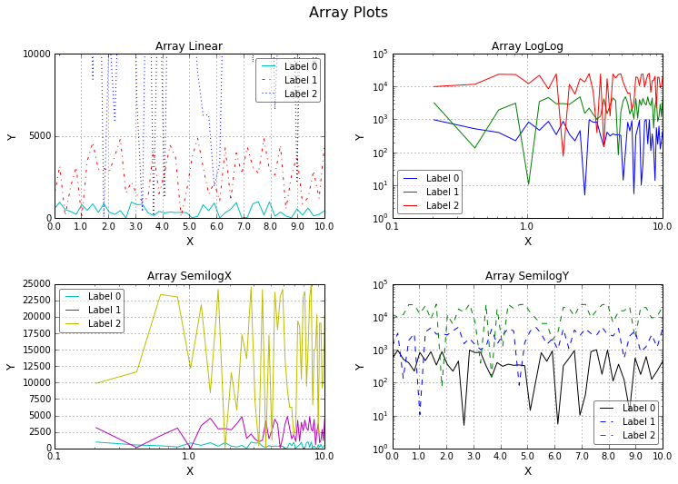

```python
x, a, labels = createRandomColumns(3, 1e3, 5.)

A = ryplot.Plotter(1, 2, 2,'Array Plots',figsize=(12,8))
A.plot(1, x, a, "Array Linear","X", "Y",label=labels,
    plotCol=['c','r','b'],linestyle=['-','-.',':'],
    legendAlpha=0.5,pltaxis=[0, 10, 0, 10000], maxNX=10, maxNY=2)
A.logLog(2, x, a, "Array LogLog","X", "Y",label=labels,legendAlpha=0.5)
A.semilogX(3, x, a, "Array SemilogX","X", "Y",label=labels,legendAlpha=0.5)
A.semilogY(4, x, a, "Array SemilogY","X", "Y",label=labels,legendAlpha=0.5)
```

To be completed.

## Python and [module versions, and dates](http://nbviewer.ipython.org/github/jrjohansson/scientific-python-lectures/blob/master/Lecture-0-Scientific-Computing-with-Python.ipynb)

```python
%load_ext version_information
%version_information numpy, scipy, matplotlib, pyradi
```

| Software | Version |
| --- | --- |
| Python | 2.7.3 (default, Apr 10 2012, 23:31:26) [MSC v.1500 32 bit (Intel)] |
| IPython | 2.0.0 |
| OS | nt [win32] |
| numpy | 1.8.0 |
| scipy | 0.13.3 |
| matplotlib | 1.3.1 |
| pyradi | 0.1.39 |
| Sat Apr 05 09:39:52 2014 South Africa Standard Time |  |